# HumanActivityRecognition case-study

### 6.7.3.6. Taking the number of neurons as 128 and drop-out value as 0.75

```python
model_4_1=lstm_model(128,0.75,1)
```

```
_________________________________________________________________
Layer (type)                 Output Shape              Param #
=================================================================
lstm_33 (LSTM)               (None, 128)               70656
_________________________________________________________________
dropout_30 (Dropout)         (None, 128)               0
_________________________________________________________________
dense_30 (Dense)             (None, 6)                 774
=================================================================
Total params: 71,430
Trainable params: 71,430
Non-trainable params: 0
_________________________________________________________________
```

```python
train_4_1=train(X_train,Y_train,X_test, Y_test,64,30,model_4_1)
```

```
Train on 7352 samples, validate on 2947 samples
 - 32s - loss: 3.7256 - acc: 0.3920 - val_loss: 3.5065 - val_acc: 0.3441
 - 29s - loss: 3.1490 - acc: 0.4837 - val_loss: 3.1700 - val_acc: 0.4153
 - 29s - loss: 2.7626 - acc: 0.4966 - val_loss: 2.5844 - val_acc: 0.5029
 - 30s - loss: 2.3055 - acc: 0.5264 - val_loss: 2.0685 - val_acc: 0.5606
 - 30s - loss: 1.8926 - acc: 0.5715 - val_loss: 1.7402 - val_acc: 0.6149
 - 30s - loss: 1.6156 - acc: 0.6064 - val_loss: 1.6212 - val_acc: 0.5477
 - 30s - loss: 1.4091 - acc: 0.6175 - val_loss: 1.3276 - val_acc: 0.6013
 - 30s - loss: 1.1595 - acc: 0.6383 - val_loss: 1.1000 - val_acc: 0.6043
 - 30s - loss: 0.9437 - acc: 0.6519 - val_loss: 0.9340 - val_acc: 0.6216
 - 30s - loss: 0.9565 - acc: 0.6299 - val_loss: 0.9670 - val_acc: 0.5803
 - 30s - loss: 0.7591 - acc: 0.6508 - val_loss: 0.8622 - val_acc: 0.5765
 - 29s - loss: 0.6978 - acc: 0.6590 - val_loss: 0.7220 - val_acc: 0.6223
 - 30s - loss: 0.7188 - acc: 0.6570 - val_loss: 0.8565 - val_acc: 0.6064
 - 30s - loss: 0.7438 - acc: 0.6492 - val_loss: 0.7556 - val_acc: 0.6152
 - 30s - loss: 0.6465 - acc: 0.6791 - val_loss: 0.7188 - val_acc: 0.6366
 - 29s - loss: 0.6323 - acc: 0.6726 - val_loss: 0.7269 - val_acc: 0.6166
 - 29s - loss: 0.7210 - acc: 0.6579 - val_loss: 3.0968 - val_acc: 0.4825
 - 29s - loss: 0.7829 - acc: 0.6451 - val_loss: 0.6934 - val_acc: 0.6278
 - 29s - loss: 0.6731 - acc: 0.6572 - val_loss: 0.7198 - val_acc: 0.6454
 - 29s - loss: 0.5919 - acc: 0.6980 - val_loss: 1.0953 - val_acc: 0.6586
 - 30s - loss: 0.5319 - acc: 0.7870 - val_loss: 0.9875 - val_acc: 0.7268
 - 29s - loss: 0.4391 - acc: 0.8316 - val_loss: 0.6024 - val_acc: 0.7543
 - 30s - loss: 0.4147 - acc: 0.8343 - val_loss: 0.5896 - val_acc: 0.7669
 - 30s - loss: 0.3546 - acc: 0.8856 - val_loss: 0.5453 - val_acc: 0.7933
 - 30s - loss: 0.3077 - acc: 0.9090 - val_loss: 0.4952 - val_acc: 0.8806
 - 30s - loss: 0.2840 - acc: 0.9142 - val_loss: 0.4607 - val_acc: 0.8792
 - 30s - loss: 0.2587 - acc: 0.9203 - val_loss: 0.8064 - val_acc: 0.8022
 - 30s - loss: 0.2599 - acc: 0.9232 - val_loss: 0.4176 - val_acc: 0.8660
 - 30s - loss: 0.2412 - acc: 0.9274 - val_loss: 0.4691 - val_acc: 0.8856
 - 30s - loss: 0.2080 - acc: 0.9340 - val_loss: 0.4679 - val_acc: 0.8965
```

```
[[510   0  27   0   0   0]
 [  0 335 156   0   0   0]
 [  0  45 487   0   0   0]
 [  0   0   1 457  34   4]
 [  0   0   0   1 412   7]
 [  0   0   0  21   9 441]]
```

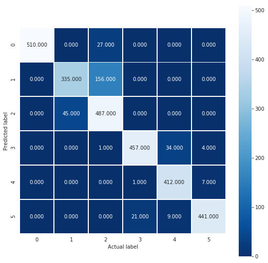

```
Pred                LAYING  SITTING  STANDING  WALKING  WALKING_DOWNSTAIRS  \
True
LAYING                 510        0        27        0                   0
SITTING                  0      335       156        0                   0
STANDING                 0       45       487        0                   0
WALKING                  0        0         1      457                  34
WALKING_DOWNSTAIRS       0        0         0        1                 412
WALKING_UPSTAIRS         0        0         0       21                   9

Pred                WALKING_UPSTAIRS
True
LAYING                             0
SITTING                            0
STANDING                           0
WALKING                            4
WALKING_DOWNSTAIRS                 7
WALKING_UPSTAIRS                 441
```

```python
# Confusion Matrix
print(confusion_matrix(Y_test, model_4_1.predict(X_test)))
```

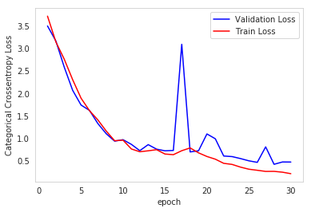

```python
# Plot weight distribution using violin plot
import warnings
warnings.filterwarnings(action='ignore')
plot_weights(model)
print()
print()

# Plot train and cross validation error
plot_train_cv_loss(train_4_1,epochs)
```

### 6.8. Implementing two-layered LSTM model

#### Utility function for building the architecture of a 2-layer LSTM model

```python
def lstm_model_2L(neurons1,neurons2,Dp):
    # Initiliazing the sequential model
    Model = Sequential()
    # Configuring the parameters
    Model.add(LSTM(neurons1, input_shape=(timesteps, input_dim),bias_regularizer=reg,return_sequences=True))
    Model.add(BatchNormalization())
    Model.add(Dropout(Dp))

    Model.add(LSTM(neurons2,bias_regularizer=reg))
    Model.add(Dropout(Dp))

    # Adding a dense output layer with sigmoid activation
    Model.add(Dense(n_classes, activation='sigmoid'))
    Model.summary()
    # Compiling the model
    Model.compile(loss='categorical_crossentropy',optimizer='adam',metrics=['accuracy'])

    return Model
```

### 6.8.1 Two layered LSTM model with 48,32 neurons and 0.6 drop-out

```python
model_2l_1=lstm_model_2L(48,32,0.6)
```

```
_________________________________________________________________
Layer (type)                 Output Shape              Param #
=================================================================
lstm_54 (LSTM)               (None, 128, 48)           11136
_________________________________________________________________
batch_normalization_6 (Batch (None, 128, 48)           192
_________________________________________________________________
dropout_40 (Dropout)         (None, 128, 48)           0
_________________________________________________________________
lstm_55 (LSTM)               (None, 32)                10368
_________________________________________________________________
dropout_41 (Dropout)         (None, 32)                0
_________________________________________________________________
dense_32 (Dense)             (None, 6)                 198
=================================================================
Total params: 21,894
Trainable params: 21,798
Non-trainable params: 96
_________________________________________________________________
```

```python
train_2l_1=train(X_train,Y_train,X_test, Y_test,128,30,model_2l_1)
```

```
Train on 7352 samples, validate on 2947 samples
 - 27s - loss: 3.0369 - acc: 0.4739 - val_loss: 2.8159 - val_acc: 0.5137
 - 23s - loss: 2.5733 - acc: 0.6136 - val_loss: 2.4458 - val_acc: 0.6485
 - 23s - loss: 2.2431 - acc: 0.6538 - val_loss: 2.2168 - val_acc: 0.6871
 - 23s - loss: 2.0099 - acc: 0.6795 - val_loss: 1.8880 - val_acc: 0.6827
 - 23s - loss: 1.8184 - acc: 0.7164 - val_loss: 1.7817 - val_acc: 0.6485
 - 23s - loss: 1.6652 - acc: 0.7418 - val_loss: 1.5462 - val_acc: 0.8120
 - 23s - loss: 1.5083 - acc: 0.7737 - val_loss: 2.2952 - val_acc: 0.4248
 - 24s - loss: 1.3695 - acc: 0.7933 - val_loss: 1.5605 - val_acc: 0.6515
 - 23s - loss: 1.2513 - acc: 0.8139 - val_loss: 1.1558 - val_acc: 0.8208
 - 24s - loss: 1.1295 - acc: 0.8345 - val_loss: 1.1076 - val_acc: 0.8124
 - 24s - loss: 1.0395 - acc: 0.8334 - val_loss: 1.0189 - val_acc: 0.8368
 - 23s - loss: 0.9161 - acc: 0.8708 - val_loss: 0.8522 - val_acc: 0.8649
 - 24s - loss: 0.8217 - acc: 0.8851 - val_loss: 0.7908 - val_acc: 0.8724
 - 24s - loss: 0.7500 - acc: 0.8875 - val_loss: 0.7071 - val_acc: 0.8724
 - 23s - loss: 0.6877 - acc: 0.8973 - val_loss: 0.7332 - val_acc: 0.8565
 - 24s - loss: 0.6225 - acc: 0.9019 - val_loss: 1.0125 - val_acc: 0.7431
 - 23s - loss: 0.5485 - acc: 0.9108 - val_loss: 0.6371 - val_acc: 0.8327
 - 23s - loss: 0.4831 - acc: 0.9226 - val_loss: 0.5953 - val_acc: 0.8578
 - 24s - loss: 0.4425 - acc: 0.9172 - val_loss: 0.4303 - val_acc: 0.8894
 - 23s - loss: 0.4014 - acc: 0.9238 - val_loss: 0.6079 - val_acc: 0.8582
 - 23s - loss: 0.3632 - acc: 0.9214 - val_loss: 0.3417 - val_acc: 0.8996
 - 23s - loss: 0.3236 - acc: 0.9285 - val_loss: 0.4791 - val_acc: 0.8568
 - 23s - loss: 0.2817 - acc: 0.9285 - val_loss: 0.3980 - val_acc: 0.8744
 - 23s - loss: 0.2583 - acc: 0.9241 - val_loss: 0.2879 - val_acc: 0.9094
 - 24s - loss: 0.2457 - acc: 0.9350 - val_loss: 0.3712 - val_acc: 0.8809
 - 24s - loss: 0.2405 - acc: 0.9346 - val_loss: 0.3276 - val_acc: 0.9074
 - 24s - loss: 0.2411 - acc: 0.9293 - val_loss: 0.2473 - val_acc: 0.9138
 - 24s - loss: 0.2232 - acc: 0.9354 - val_loss: 0.2467 - val_acc: 0.9199
 - 24s - loss: 0.2146 - acc: 0.9376 - val_loss: 0.3407 - val_acc: 0.9036
 - 23s - loss: 0.2092 - acc: 0.9370 - val_loss: 0.2597 - val_acc: 0.9172
```

```
[[537   0   0   0   0   0]
 [  0 407  80   1   3   0]
 [  0  97 435   0   0   0]
 [  0   1   0 490   4   1]
 [  0   0   0   0 406  14]
 [  0   0   0  34   9 428]]
```

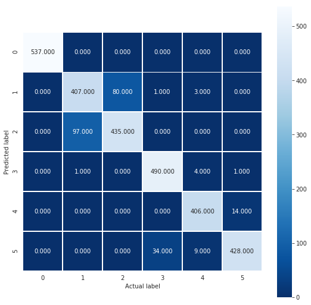

```
Pred                LAYING  SITTING  STANDING  WALKING  WALKING_DOWNSTAIRS  \
True
LAYING                 537        0         0        0                   0
SITTING                  0      407        80        1                   3
STANDING                 0       97       435        0                   0
WALKING                  0        1         0      490                   4
WALKING_DOWNSTAIRS       0        0         0        0                 406
WALKING_UPSTAIRS         0        0         0       34                   9

Pred                WALKING_UPSTAIRS
True
LAYING                             0
SITTING                            0
STANDING                           0
WALKING                            1
WALKING_DOWNSTAIRS                14
WALKING_UPSTAIRS                 428
```

```python
# Confusion Matrix
print(confusion_matrix(Y_test,model_2l_1.predict(X_test)))
```

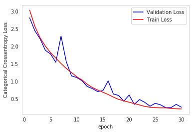

```python
# Plot weight distribution using violin plot
import warnings
warnings.filterwarnings(action='ignore')
plot_weights(model)
print()
print()

# Plot train and cross validation error
plot_train_cv_loss(train_2l_1,epochs)
```

### 6.8.2 Two layered LSTM model with 68,48 neurons and 0.75 drop-out

```python
model_2l_2=lstm_model_2L(68,48,0.75)
```

```
_________________________________________________________________
Layer (type)                 Output Shape              Param #
=================================================================
lstm_56 (LSTM)               (None, 128, 68)           21216
_________________________________________________________________
batch_normalization_7 (Batch (None, 128, 68)           272
_________________________________________________________________
dropout_42 (Dropout)         (None, 128, 68)           0
_________________________________________________________________
lstm_57 (LSTM)               (None, 48)                22464
_________________________________________________________________
dropout_43 (Dropout)         (None, 48)                0
_________________________________________________________________
dense_33 (Dense)             (None, 6)                 294
=================================================================
Total params: 44,246
Trainable params: 44,110
Non-trainable params: 136
_________________________________________________________________
```

```python
train_2l_2=train(X_train,Y_train,X_test, Y_test,128,30,model_2l_2)
```

```
Train on 7352 samples, validate on 2947 samples
 - 39s - loss: 3.7437 - acc: 0.4460 - val_loss: 3.4338 - val_acc: 0.4917
 - 36s - loss: 3.2116 - acc: 0.5823 - val_loss: 3.2978 - val_acc: 0.4041
 - 36s - loss: 2.8100 - acc: 0.6356 - val_loss: 2.5696 - val_acc: 0.6980
 - 35s - loss: 2.5396 - acc: 0.6752 - val_loss: 2.3058 - val_acc: 0.7163
 - 35s - loss: 2.2923 - acc: 0.7184 - val_loss: 2.1641 - val_acc: 0.7268
 - 35s - loss: 2.0834 - acc: 0.7554 - val_loss: 1.8648 - val_acc: 0.7754
 - 35s - loss: 1.8829 - acc: 0.7811 - val_loss: 1.8323 - val_acc: 0.7289
 - 35s - loss: 1.7385 - acc: 0.7860 - val_loss: 1.7661 - val_acc: 0.7930
 - 35s - loss: 1.5741 - acc: 0.8300 - val_loss: 1.3736 - val_acc: 0.8568
 - 35s - loss: 1.4073 - acc: 0.8502 - val_loss: 1.2503 - val_acc: 0.8616
 - 35s - loss: 1.2319 - acc: 0.8833 - val_loss: 1.0695 - val_acc: 0.8924
 - 35s - loss: 1.0842 - acc: 0.9017 - val_loss: 1.4219 - val_acc: 0.7662
 - 35s - loss: 1.0828 - acc: 0.8632 - val_loss: 1.2207 - val_acc: 0.7954
 - 35s - loss: 0.9473 - acc: 0.8780 - val_loss: 0.9101 - val_acc: 0.8697
 - 35s - loss: 0.8736 - acc: 0.8766 - val_loss: 1.1530 - val_acc: 0.7523
 - 35s - loss: 0.7916 - acc: 0.8882 - val_loss: 0.8649 - val_acc: 0.8035
 - 35s - loss: 0.6822 - acc: 0.8958 - val_loss: 0.7669 - val_acc: 0.8476
 - 36s - loss: 0.5822 - acc: 0.9150 - val_loss: 0.8482 - val_acc: 0.8235
 - 36s - loss: 0.5190 - acc: 0.9147 - val_loss: 0.5431 - val_acc: 0.8748
 - 35s - loss: 0.4614 - acc: 0.9185 - val_loss: 0.4581 - val_acc: 0.8979
 - 35s - loss: 0.4182 - acc: 0.9123 - val_loss: 0.5880 - val_acc: 0.8534
 - 35s - loss: 0.3619 - acc: 0.9219 - val_loss: 0.4182 - val_acc: 0.8816
 - 35s - loss: 0.3290 - acc: 0.9222 - val_loss: 0.5385 - val_acc: 0.8663
 - 35s - loss: 0.3096 - acc: 0.9199 - val_loss: 0.6696 - val_acc: 0.8351
 - 35s - loss: 0.2938 - acc: 0.9237 - val_loss: 0.4134 - val_acc: 0.8738
 - 35s - loss: 0.2712 - acc: 0.9270 - val_loss: 0.5353 - val_acc: 0.8595
 - 35s - loss: 0.2798 - acc: 0.9177 - val_loss: 0.4545 - val_acc: 0.8504
 - 35s - loss: 0.3590 - acc: 0.9134 - val_loss: 0.7247 - val_acc: 0.8008
 - 35s - loss: 0.2882 - acc: 0.9230 - val_loss: 0.3731 - val_acc: 0.8901
 - 36s - loss: 0.2501 - acc: 0.9313 - val_loss: 0.3799 - val_acc: 0.8843
```

```
[[510   0   0   0   0  27]
 [  0 423  62   0   0   6]
 [  0 136 396   0   0   0]
 [  0   0   0 466  20  10]
 [  0   0   0   3 409   8]
 [  0   0   0  41  28 402]]
```

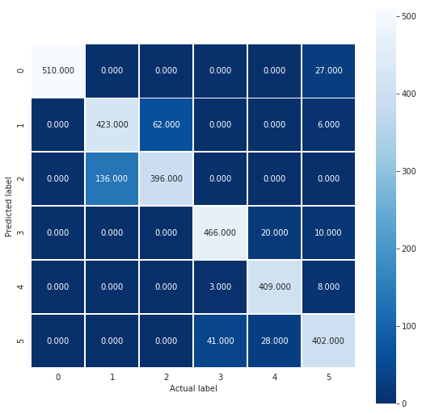

```
Pred                LAYING  SITTING  STANDING  WALKING  WALKING_DOWNSTAIRS  \
True
LAYING                 510        0         0        0                   0
SITTING                  0      423        62        0                   0
STANDING                 0      136       396        0                   0
WALKING                  0        0         0      466                  20
WALKING_DOWNSTAIRS       0        0         0        3                 409
WALKING_UPSTAIRS         0        0         0       41                  28

Pred                WALKING_UPSTAIRS
True
LAYING                            27
SITTING                            6
STANDING                           0
WALKING                           10
WALKING_DOWNSTAIRS                 8
WALKING_UPSTAIRS                 402
```

```python
# Confusion Matrix
print(confusion_matrix(Y_test,model_2l_2.predict(X_test)))
```

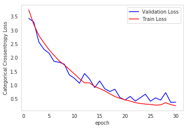

```python
# Plot weight distribution using violin plot
import warnings
warnings.filterwarnings(action='ignore')
plot_weights(model)
print()
print()

# Plot train and cross validation error
plot_train_cv_loss(train_2l_2,epochs)
```

```python
model_2l_3=lstm_model_2L(128,128,0.85)
```

[output not shown]

```python
train_2l_3=train(X_train,Y_train,X_test, Y_test,198,30,model_2l_3)
```

```
Train on 7352 samples, validate on 2947 samples
 - 71s - loss: 1.4969 - acc: 0.6559 - val_loss: 1.6184 - val_acc: 0.6403
 - 72s - loss: 1.4084 - acc: 0.6575 - val_loss: 1.5060 - val_acc: 0.6417
 - 72s - loss: 1.3269 - acc: 0.6642 - val_loss: 1.3017 - val_acc: 0.6719
 - 72s - loss: 1.2506 - acc: 0.6640 - val_loss: 1.4520 - val_acc: 0.6308
 - 73s - loss: 1.1677 - acc: 0.6593 - val_loss: 1.2104 - val_acc: 0.6420
 - 74s - loss: 1.0977 - acc: 0.6649 - val_loss: 1.3235 - val_acc: 0.6420
 - 73s - loss: 1.0288 - acc: 0.6732 - val_loss: 1.0335 - val_acc: 0.6593
 - 74s - loss: 0.9526 - acc: 0.6772 - val_loss: 1.0337 - val_acc: 0.6566
 - 74s - loss: 0.8877 - acc: 0.6870 - val_loss: 0.9647 - val_acc: 0.6440
 - 73s - loss: 0.8366 - acc: 0.6770 - val_loss: 0.8706 - val_acc: 0.6770
 - 73s - loss: 0.7675 - acc: 0.6880 - val_loss: 0.8022 - val_acc: 0.6478
 - 73s - loss: 0.7212 - acc: 0.6896 - val_loss: 1.3917 - val_acc: 0.6210
 - 73s - loss: 0.6640 - acc: 0.7038 - val_loss: 0.6284 - val_acc: 0.6882
 - 73s - loss: 0.6438 - acc: 0.7074 - val_loss: 0.7523 - val_acc: 0.6719
 - 73s - loss: 0.6266 - acc: 0.7175 - val_loss: 0.6535 - val_acc: 0.6912
 - 74s - loss: 0.6169 - acc: 0.7214 - val_loss: 0.6166 - val_acc: 0.6725
 - 73s - loss: 0.6090 - acc: 0.7303 - val_loss: 0.7029 - val_acc: 0.6793
 - 73s - loss: 0.5948 - acc: 0.7391 - val_loss: 0.6560 - val_acc: 0.7072
 - 74s - loss: 0.5814 - acc: 0.7462 - val_loss: 0.8362 - val_acc: 0.7988
 - 73s - loss: 0.6133 - acc: 0.7515 - val_loss: 0.9580 - val_acc: 0.7618
 - 73s - loss: 0.5794 - acc: 0.7696 - val_loss: 0.5727 - val_acc: 0.8534
 - 76s - loss: 0.5343 - acc: 0.7912 - val_loss: 0.6593 - val_acc: 0.7954
 - 76s - loss: 0.5266 - acc: 0.8025 - val_loss: 0.6217 - val_acc: 0.8113
 - 76s - loss: 0.5181 - acc: 0.8150 - val_loss: 0.5580 - val_acc: 0.8741
 - 77s - loss: 0.5002 - acc: 0.8364 - val_loss: 0.7744 - val_acc: 0.8419
 - 77s - loss: 0.4999 - acc: 0.8232 - val_loss: 0.9647 - val_acc: 0.8083
 - 76s - loss: 0.4958 - acc: 0.8225 - val_loss: 0.6814 - val_acc: 0.8269
 - 76s - loss: 0.5140 - acc: 0.8300 - val_loss: 1.1205 - val_acc: 0.6749
 - 76s - loss: 0.5945 - acc: 0.7958 - val_loss: 1.2269 - val_acc: 0.5348
 - 77s - loss: 0.4990 - acc: 0.8283 - val_loss: 0.4161 - val_acc: 0.8592
```

```
[[510   0   0   0   0  27]
 [  0 423  62   0   0   6]
 [  0 136 396   0   0   0]
 [  0   0   0 466  20  10]
 [  0   0   0   3 409   8]
 [  0   0   0  41  28 402]]
```

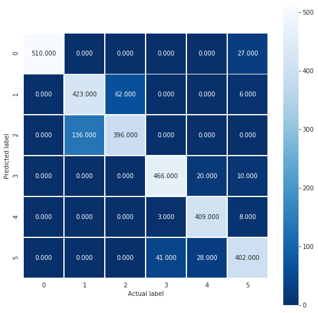

```
Pred                LAYING  SITTING  STANDING  WALKING  WALKING_DOWNSTAIRS  \
True
LAYING                 510        0         0        0                   0
SITTING                  0      423        62        0                   0
STANDING                 0      136       396        0                   0
WALKING                  0        0         0      466                  20
WALKING_DOWNSTAIRS       0        0         0        3                 409
WALKING_UPSTAIRS         0        0         0       41                  28

Pred                WALKING_UPSTAIRS
True
LAYING                            27
SITTING                            6
STANDING                           0
WALKING                           10
WALKING_DOWNSTAIRS                 8
WALKING_UPSTAIRS                 402
```

```python
# Confusion Matrix
print(confusion_matrix(Y_test,model_2l_2.predict(X_test)))
```

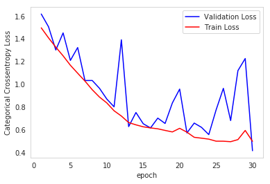

```python
# Plot weight distribution using violin plot
import warnings
warnings.filterwarnings(action='ignore')
plot_weights(model)
print()
print()

# Plot train and cross validation error
plot_train_cv_loss(train_2l_3,epochs)
```

### Observations:-

- In the 2-layered LSTM architecture I have tried various combinations of neurons and drop-outs values and all gave good results with accuracy more than 90% except the last architecture.
- The 2-layered LSTM with (48,32) set of neurons and 0.6 drop-out rates have the best accuracy which is 93.70 with a error rate of 20%.
- The models with higher dropout rates tends to have higher error rates since the data is less.

```python
def conclusion_table1():
    print()
    ptable=PrettyTable()
    ptable.title="The performance comparisons of all the Machine-learning algorithms are as follows: "
    ptable.field_names=["Algorithm","Accuracy","Error-rates"]
    ptable.add_row(["Logistic-regression",96.3,3.69])
    ptable.add_row(["Linear SVM",96.64,3.35])
    ptable.add_row(["RBF-Kernel SVM",96.27,3.73])
    ptable.add_row(["Decision Tree",86.49,13.51])
    ptable.add_row(["Random-forest",91.35,8.65])
    ptable.add_row(["Gradient-boosted Decsion tree",91.35,8.653])
    print(ptable)

def conclusion_table2():
    print()
    ptable=PrettyTable()
    ptable.title="The performance comparisons of all the single layered LSTM model are as follows: "
    ptable.field_names=["Number of neurons","Drop-out_rates","Percentage_Accuracy","Percentage_Loss"]
    ptable.add_row([48,0.6,91.53,30])
    ptable.add_row([48,0.75,65,67])
    ptable.add_row([64,0.6,93.61,19])
    ptable.add_row([64,0.75,91.95,25])
    ptable.add_row([128,0.6,94.41,14])
    ptable.add_row([128,0.75,93.40,20])

    Ptable=PrettyTable()
    Ptable.title="The performance comparisons of all the 2-Layered LSTM models are as follows: "
    Ptable.field_names=["Neuron in layer_1","Neuron in layer_2","Drop-out_rates","Percentage_Accuracy","Percentage_Loss"]
    Ptable.add_row([48,32,0.6,93.70,20.9])
    Ptable.add_row([68,48,0.75,93.13,25.01])
    Ptable.add_row([128,64,0.85,82.83,49.90])
    print(ptable)
    print(Ptable)
```

```python
conclusion_table1()
conclusion_table2()
```

```
+-------------------------------------------------------------------------------------+
| The performance comparisons of all the Machine-learning algorithms are as follows:  |
+------------------------------------------------+---------------+--------------------+
|                   Algorithm                    |    Accuracy   |    Error-rates     |
+------------------------------------------------+---------------+--------------------+
|              Logistic-regression               |      96.3     |        3.69        |
|                   Linear SVM                   |     96.64     |        3.35        |
|                 RBF-Kernel SVM                 |     96.27     |        3.73        |
|                 Decision Tree                  |     86.49     |       13.51        |
|                 Random-forest                  |     91.35     |        8.65        |
|         Gradient-boosted Decsion tree          |     91.35     |       8.653        |
+------------------------------------------------+---------------+--------------------+

+--------------------------------------------------------------------------------------+
|  The performance comparisons of all the single layered LSTM model are as follows:    |
+----------------------+------------------+------------------------+-------------------+
|  Number of neurons   |  Drop-out_rates  |  Percentage_Accuracy   |  Percentage_Loss  |
+----------------------+------------------+------------------------+-------------------+
|          48          |       0.6        |         91.53          |         30        |
|          48          |       0.75       |           65           |         67        |
|          64          |       0.6        |         93.61          |         19        |
|          64          |       0.75       |         91.95          |         25        |
|         128          |       0.6        |         94.41          |         14        |
|         128          |       0.75       |          93.4          |         20        |
+----------------------+------------------+------------------------+-------------------+
+------------------------------------------------------------------------------------------------+
|         The performance comparisons of all the 2-Layered LSTM models are as follows:           |
+-------------------+-------------------+----------------+---------------------+-----------------+
| Neuron in layer_1 | Neuron in layer_2 | Drop-out_rates | Percentage_Accuracy | Percentage_Loss |
+-------------------+-------------------+----------------+---------------------+-----------------+
|         48        |         32        |      0.6       |         93.7        |       20.9      |
|         68        |         48        |      0.75      |        93.13        |      25.01      |
|        128        |         64        |      0.85      |        82.83        |       49.9      |
+-------------------+-------------------+----------------+---------------------+-----------------+
```

# Conclusion

- In this above case-study of Human-activity-recognition system the expert engineered features plays an important role for developing proper supervised machine-learning models with greater accuracy and lesser error values.
- So in machine-learning domain knowledge cannot be completely ignored as it is a key tool in solving complex real life problems but it is a slow and tedious process.
- To fast up the process the deep-learning models are used and especially in sequenced data as input LSTM models are used widely.These models can automatically learn the features as raw input is given to it.
- In this case-study raw input vectors which are prepared by using the over-lapped sampling techniques over the 9-signal data.
- No expert features are given as input and the LSTM model learned the features over time and gave pretty descent accuracy and error-rates.
- After tuning the hyper-parameters of a single layered LSTM I got an accuracy around 94.41% which is pretty close to the accuracy of the machine-learning model which was build using the expert-engineered features.
- So clearly with larger dataset and deeper layers the Deep-Learning model can surpass the performance of the machine-learning models.
- It is very easy to over-fitt an deep-learning model so to avoid it proper regularization is neccessary which can be done by Drop-out layers and regulating the layers in a Deep-learning model.